# Week 3 - Lectures & Quick Questions

Vishal Gupta

3/30/2019

```r
library(dplyr)
library(caTools)
library(ROCR)
```

## Modeling the Expert: An Introduction to Logistic Regression

#### Video 4: Logistic Regression in R

Loading the dataset

```r
quality = read.csv("~/Downloads/quality.csv")
str(quality)
```

```
## 'data.frame':    131 obs. of  14 variables:
##  $ MemberID            : int  1 2 3 4 5 6 7 8 9 10 ...
##  $ InpatientDays       : int  0 1 0 0 8 2 16 2 2 4 ...
##  $ ERVisits            : int  0 1 0 1 2 0 1 0 1 2 ...
##  $ OfficeVisits        : int  18 6 5 19 19 9 8 8 4 0 ...
##  $ Narcotics           : int  1 1 3 0 3 2 1 0 3 2 ...
##  $ DaysSinceLastERVisit: num  731 411 731 158 449 ...
##  $ Pain                : int  10 0 10 34 10 6 4 5 5 2 ...
##  $ TotalVisits         : int  18 8 5 20 29 11 25 10 7 6 ...
##  $ ProviderCount       : int  21 27 16 14 24 40 19 11 28 21 ...
##  $ MedicalClaims       : int  93 19 27 59 51 53 40 28 20 17 ...
##  $ ClaimLines          : int  222 115 148 242 204 156 261 87 98 66 ...
##  $ StartedOnCombination: logi  FALSE FALSE FALSE FALSE FALSE FALSE ...
##  $ AcuteDrugGapSmall   : int  0 1 5 0 0 4 0 0 0 0 ...
##  $ PoorCare            : int  0 0 0 0 0 1 0 0 1 0 ...
```

Distibution of target

```r
table(quality$PoorCare)
```

```
##
##  0  1
## 98 33
```

Baseline accuracy

```r
98/131
```

```
## [1] 0.7480916
```

Install and load caTools packages - Tools for moving window statistics, GIF, Base64, ROC AUC,

```r
#install.packages("caTools")
library(caTools)
```

Randomly split data on `PoorCare` : 75% for Training and 25% for testing

Randomly split data on `PoorCase` : 75% for Training & 25% Testing

```r
set.seed(88)
split = sample.split(quality$PoorCare, SplitRatio = 0.75)
qualityTrain = subset(quality, split == TRUE)
qualityTest = subset(quality, split == FALSE)
```

Creating Logistic Regression Model to predict `PoorCare` using `OfficeVisits` and `Narcotics`

```r
QualityLog = glm(PoorCare ~ OfficeVisits + Narcotics, data=qualityTrain, family=binomial)
summary(QualityLog)
```

```
##
## Call:
## glm(formula = PoorCare ~ OfficeVisits + Narcotics, family = binomial,
##     data = qualityTrain)
##
## Deviance Residuals:
##      Min        1Q    Median        3Q       Max
## -2.06303  -0.63155  -0.50503  -0.09689   2.16686
##
## Coefficients:
##              Estimate Std. Error z value Pr(>|z|)
## (Intercept)  -2.64613    0.52357  -5.054 4.33e-07 ***
## OfficeVisits  0.08212    0.03055   2.688  0.00718 **
## Narcotics     0.07630    0.03205   2.381  0.01728 *
## ---
## Signif. codes:  0 '***' 0.001 '**' 0.01 '*' 0.05 '.' 0.1 ' ' 1
##
## (Dispersion parameter for binomial family taken to be 1)
##
##     Null deviance: 111.888  on 98  degrees of freedom
## Residual deviance:  89.127  on 96  degrees of freedom
## AIC: 95.127
##
## Number of Fisher Scoring iterations: 4
```

Make predictions on training set

```r
predictTrain = predict(QualityLog, type="response")
```

```r
summary(predictTrain)
```

```
##    Min. 1st Qu.  Median    Mean 3rd Qu.    Max.
## 0.06623 0.11912 0.15967 0.25253 0.26765 0.98456
```

```r
tapply(predictTrain, qualityTrain$PoorCare, mean)
```

```
##         0         1
## 0.1894512 0.4392246
```

#### Quick Question

What is the coefficient for “StartedOnCombination”?

```r
QualityLog2 = glm(PoorCare ~ ProviderCount + StartedOnCombination, data=qualityTrain, family=binomial)
summary(QualityLog2)
```

```
##
## Call:
## glm(formula = PoorCare ~ ProviderCount + StartedOnCombination,
##     family = binomial, data = qualityTrain)
##
## Deviance Residuals:
##      Min        1Q    Median        3Q       Max
## -1.61826  -0.72782  -0.64555  -0.08407   1.94662
##
## Coefficients:
##                          Estimate Std. Error z value Pr(>|z|)
## (Intercept)              -2.00097    0.55097  -3.632 0.000282 ***
## ProviderCount             0.03366    0.01983   1.697 0.089706 .
## StartedOnCombinationTRUE  1.95230    1.22342   1.596 0.110541
## ---
## Signif. codes:  0 '***' 0.001 '**' 0.01 '*' 0.05 '.' 0.1 ' ' 1
##
## (Dispersion parameter for binomial family taken to be 1)
##
##     Null deviance: 111.89  on 98  degrees of freedom
## Residual deviance: 104.37  on 96  degrees of freedom
## AIC: 110.37
##
## Number of Fisher Scoring iterations: 4
```

StartedOnCombination is a binary variable, which equals 1 if the patient is started on a combination of drugs to treat their diabetes, and equals 0 if the patient is not started on a combination of drugs. All else being equal, does this model imply that starting a patient on a combination of drugs is indicative of poor care, or good care?

- **Poor Care**
- Good Care

#### Video 5: Thresholding

Confusion matrix with threshold = 0.5

```r
table(qualityTrain$PoorCare, predictTrain > 0.5)
```

```
##
##     FALSE TRUE
##   0    70    4
##   1    15   10
```

Sensitivity and Specificity

```r
10/25
```

```
## [1] 0.4
```

```r
70/74
```

```
## [1] 0.9459459
```

Confusion matrix with threshold = 0.7

```r
table(qualityTrain$PoorCare, predictTrain > 0.7)
```

```
##
##     FALSE TRUE
##   0    73    1
##   1    17    8
```

Sensitivity and Specificity

```r
8/25
```

```
## [1] 0.32
```

```r
73/74
```

```
## [1] 0.9864865
```

Confusion matrix with threshold = 0.2

```r
table(qualityTrain$PoorCare, predictTrain > 0.2)
```

```
##
##     FALSE TRUE
##   0    54   20
##   1     9   16
```

Sensitivity and Specificity

```r
16/25
```

```
## [1] 0.64
```

```r
54/74
```

```
## [1] 0.7297297
```

#### Quick Question

This question asks about the following two confusion matrices:

Confusion Matrix #1:

| x | Predicted = 0 | Predicted = 1 |
| --- | --- | --- |
| Actual = 0 | 15 | 10 |
| Actual = 1 | 5 | 20 |

Confusion Matrix #2:

| x | Predicted = 0 | Predicted = 1 |
| --- | --- | --- |
| Actual = 0 | 20 | 5 |
| Actual = 1 | 10 | 15 |

#### Quick Question

What is the sensitivity of Confusion Matrix #1?

```r
20/(20+5)
```

```
## [1] 0.8
```

What is the specificity of Confusion Matrix #1?

```r
15/(15+10)
```

```
## [1] 0.6
```

#### Video 6: ROC Curves

Install and load ROCR

```r
#install.packages("ROCR")
library(ROCR)
```

Prediction

```r
ROCRpred = prediction(predictTrain, qualityTrain$PoorCare)
```

Plot ROC curves with performance

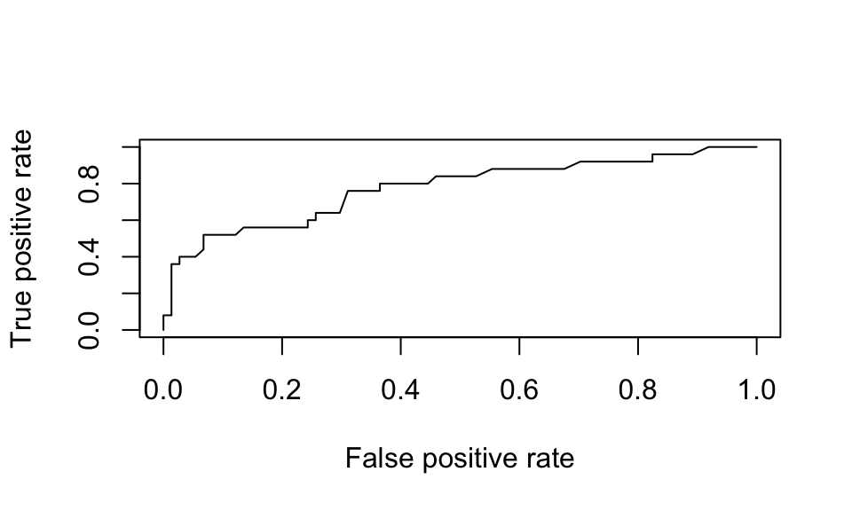

```r
ROCRperf = performance(ROCRpred, "tpr", "fpr")
plot(ROCRperf)
```

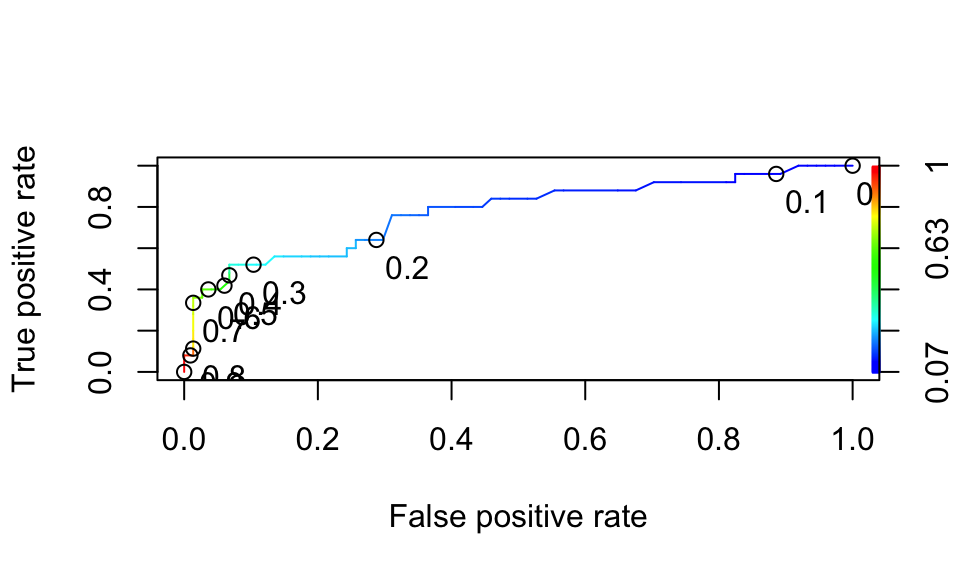

```r
plot(ROCRperf, colorize=TRUE)
plot(ROCRperf, colorize=TRUE, print.cutoffs.at=seq(0,1,by=0.1), text.adj=c(-0.2,1.7))
```

#### Quick Question

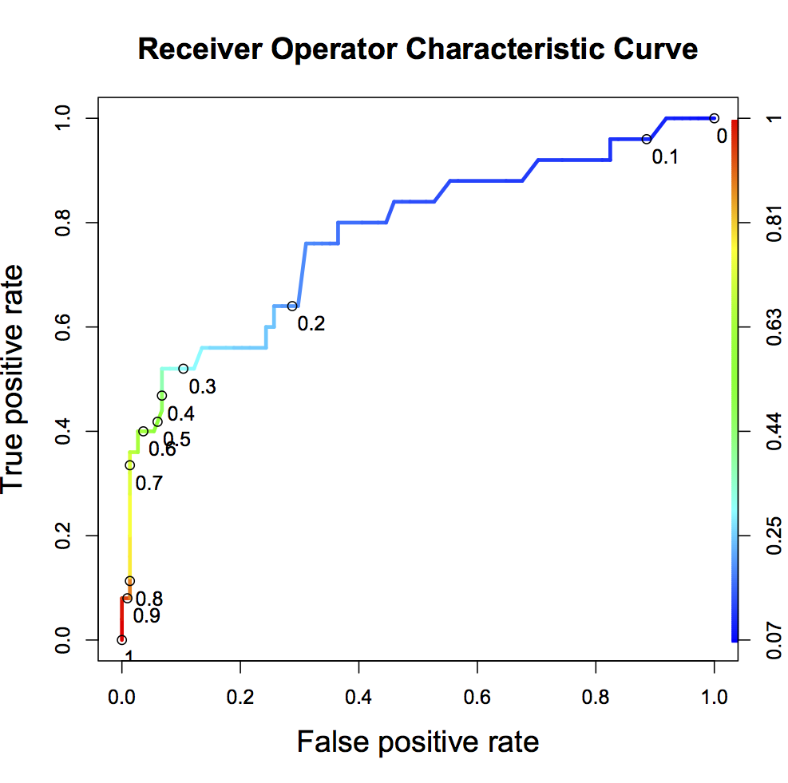

Given this ROC curve, which threshold would you pick if you wanted to correctly identify a small group of patients who are receiving the worst care with high confidence?

- t = 0.2
- t = 0.3
- **t = 0.7**
- t = 0.8

Which threshold would you pick if you wanted to correctly identify half of the patients receiving poor care, while making as few errors as possible?

- t = 0.2
- **t = 0.3**
- t = 0.7
- t = 0.8

## The Framingham Heart Study: Evaluating Risk Factors to Save Lives

#### Video 3: A Logistic Regression Model

Load the dataset

```r
framingham = read.csv("~/Downloads/framingham.csv")
str(framingham)
```

```
## 'data.frame':    4240 obs. of  16 variables:
##  $ male           : int  1 0 1 0 0 0 0 0 1 1 ...
##  $ age            : int  39 46 48 61 46 43 63 45 52 43 ...
##  $ education      : int  4 2 1 3 3 2 1 2 1 1 ...
##  $ currentSmoker  : int  0 0 1 1 1 0 0 1 0 1 ...
##  $ cigsPerDay     : int  0 0 20 30 23 0 0 20 0 30 ...
##  $ BPMeds         : int  0 0 0 0 0 0 0 0 0 0 ...
##  $ prevalentStroke: int  0 0 0 0 0 0 0 0 0 0 ...
##  $ prevalentHyp   : int  0 0 0 1 0 1 0 0 1 1 ...
##  $ diabetes       : int  0 0 0 0 0 0 0 0 0 0 ...
##  $ totChol        : int  195 250 245 225 285 228 205 313 260 225 ...
##  $ sysBP          : num  106 121 128 150 130 ...
##  $ diaBP          : num  70 81 80 95 84 110 71 71 89 107 ...
##  $ BMI            : num  27 28.7 25.3 28.6 23.1 ...
##  $ heartRate      : int  80 95 75 65 85 77 60 79 76 93 ...
##  $ glucose        : int  77 76 70 103 85 99 85 78 79 88 ...
##  $ TenYearCHD     : int  0 0 0 1 0 0 1 0 0 0 ...
```

Load the `caTools` to split data into training and testing

```r
library(caTools)
```

```r
set.seed(1000)
split = sample.split(framingham$TenYearCHD, SplitRatio = 0.65)
train = subset(framingham, split==TRUE)
test = subset(framingham, split==FALSE)
```

Train Logistic regression model to predict `TenYearCHD` from training set

```r
framinghamLog = glm(TenYearCHD ~ ., data = train, family=binomial)
summary(framinghamLog)
```

```
##
## Call:
## glm(formula = TenYearCHD ~ ., family = binomial, data = train)
##
## Deviance Residuals:
##     Min       1Q   Median       3Q      Max
## -1.8487  -0.6007  -0.4257  -0.2842   2.8369
##
## Coefficients:
##                  Estimate Std. Error z value Pr(>|z|)
## (Intercept)     -7.886574   0.890729  -8.854  < 2e-16 ***
## male             0.528457   0.135443   3.902 9.55e-05 ***
## age              0.062055   0.008343   7.438 1.02e-13 ***
## education       -0.058923   0.062430  -0.944  0.34525
## currentSmoker    0.093240   0.194008   0.481  0.63080
## cigsPerDay       0.015008   0.007826   1.918  0.05514 .
## BPMeds           0.311221   0.287408   1.083  0.27887
## prevalentStroke  1.165794   0.571215   2.041  0.04126 *
## prevalentHyp     0.315818   0.171765   1.839  0.06596 .
## diabetes        -0.421494   0.407990  -1.033  0.30156
## totChol          0.003835   0.001377   2.786  0.00533 **
## sysBP            0.011344   0.004566   2.485  0.01297 *
## diaBP           -0.004740   0.008001  -0.592  0.55353
## BMI              0.010723   0.016157   0.664  0.50689
## heartRate       -0.008099   0.005313  -1.524  0.12739
## glucose          0.008935   0.002836   3.150  0.00163 **
## ---
## Signif. codes:  0 '***' 0.001 '**' 0.01 '*' 0.05 '.' 0.1 ' ' 1
##
## (Dispersion parameter for binomial family taken to be 1)
##
##     Null deviance: 2020.7  on 2384  degrees of freedom
## Residual deviance: 1792.3  on 2369  degrees of freedom
##   (371 observations deleted due to missingness)
## AIC: 1824.3
##
## Number of Fisher Scoring iterations: 5
```

Predicting `TenYearCHD` of test samples

```r
predictTest = predict(framinghamLog, type="response", newdata=test)
```

Confusion matrix with threshold = 0.5

```r
table(test$TenYearCHD, predictTest > 0.5)
```

```
##
##     FALSE TRUE
##   0  1069    6
##   1   187   11
```

Accuracy on test set

```r
(1069+11)/(1069+6+187+11)
```

```
## [1] 0.8483896
```

Baseline accuracy on test set

```r
(1069+6)/(1069+6+187+11)
```

```
## [1] 0.8444619
```

Calculating test set AUC

```r
library(ROCR)
ROCRpred = prediction(predictTest, test$TenYearCHD)
as.numeric(performance(ROCRpred, "auc")@y.values)
```

```
## [1] 0.7421095
```

#### Quick Question

In the previous video, we computed the following confusion matrix for our logistic regression model on our test set with a threshold of 0.5:

| x | FALSE | TRUE |
| --- | --- | --- |
| 0 | 1069 | 6 |
| 1 | 187 | 11 |

Using this confusion matrix, answer the following questions.

What is the sensitivity of our logistic regression model on the test set, using a threshold of 0.5?

```r
11/(11+187)
```

```
## [1] 0.05555556
```

What is the specificity of our logistic regression model on the test set, using a threshold of 0.5?

```r
1069/(1069+6)
```

```
## [1] 0.9944186
```